# **Problem Statement**

# **Deployment - Frontend**

## Points to note before executing the below cells

- Create a Streamlit space on Hugging Face by following the instructions provided on the content page titled **`Creating Spaces and Adding Secrets in Hugging Face`** from Week 1

## Streamlit for Interactive UI

```python
# Create a folder for storing the files needed for frontend UI deployment
os.makedirs("frontend_files", exist_ok=True)
```

```python
%%writefile frontend_files/app.py

import streamlit as st
import requests

st.title("Superkart Sales Prediction App")

# Input fields for product and store data
Product_Weight = st.number_input("Product Weight", min_value=0.0, value=12.66)
Product_Sugar_Content = st.selectbox("Product Sugar Content", ["Low Sugar", "Regular", "No Sugar"])
Product_Allocated_Area = st.number_input("Product Allocated Area", min_value=0.0, max_value=1.0, value=0.05)
Product_MRP = st.number_input("Product MRP", min_value=0.0, value=147.0)

# Categorical inputs based on your EDA findings
Store_Size = st.selectbox("Store Size", ["High", "Medium", "Small"])
Store_Location_City_Type = st.selectbox("Store Location City Type", ["Tier 1", "Tier 2", "Tier 3"])
Store_Type = st.selectbox("Store Type", ["Supermarket Type1", "Supermarket Type2", "Departmental Store", "Food Mart"])

# Feature engineered inputs
Product_Id_char = st.selectbox("Product ID Category", ["FD", "DR", "NC"])
Store_Age_Years = st.number_input("Store Age (in Years)", min_value=0, value=20)
Product_Type_Category = st.selectbox("Product Type Category", ["Perishables", "Non Perishables"])

product_data = {
    "Product_Weight": Product_Weight,
    "Product_Sugar_Content": Product_Sugar_Content,
    "Product_Allocated_Area": Product_Allocated_Area,
    "Product_MRP": Product_MRP,
    "Store_Size": Store_Size,
    "Store_Location_City_Type": Store_Location_City_Type,
    "Store_Type": Store_Type,
    "Product_Id_char": Product_Id_char,
    "Store_Age_Years": Store_Age_Years,
    "Product_Type_Category": Product_Type_Category
}

if st.button("Predict", type='primary'):
    response = requests.post("https://SangeethaKumari-austinsuperkartpredictionbackend.hf.space/v1/predict", json=product_data)    # Complete the code to enter user name and space name to correctly define the endpoint
    if response.status_code == 200:
        result = response.json()
        predicted_sales = result["Sales"]
        st.write(f"Predicted Product Store Sales Total: ₹{predicted_sales:.2f}")
    else:
        st.error("Error in API request")
```

```
Writing frontend_files/app.py
```

```python
#Observation :
# Creating a front end streamlit Interactive UI for accessing the backend endpoint api v1/predict.
```

## Dependencies File

```python
%%writefile frontend_files/requirements.txt
requests==2.32.3
streamlit==1.45.0
```

```
Writing frontend_files/requirements.txt
```

## DockerFile

```python
%%writefile frontend_files/Dockerfile
# Use a minimal base image with Python 3.9 installed
FROM python:3.9-slim

# Set the working directory inside the container to /app
WORKDIR /app

# Copy all files from the current directory on the host to the container's /app directory
COPY . .

# Install Python dependencies listed in requirements.txt
RUN pip3 install -r requirements.txt

# Define the command to run the Streamlit app on port 7860 and make it accessible externally
CMD ["streamlit", "run", "app.py", "--server.port=7860", "--server.address=0.0.0.0", "--server.enableXsrfProtection=false"]

# NOTE: Disable XSRF protection for easier external access in order to make batch predictions
```

```
Overwriting frontend_files/Dockerfile
```

```python
# Try to create the repository for the Hugging Face Space for the front end
try:
    create_repo("SangeethaKumari/austinsuperkartpredictionfrontend",
        repo_type="space",  # Specify the repository type as "space"
        space_sdk="docker",  # Specify the space SDK as "docker"
        private=False  # Set to True if you want the space to be private
    )
except Exception as e:
    # Handle potential errors during repository creation
    if "RepositoryAlreadyExistsError" in str(e):
        print("Repository already exists. Skipping creation.")
    else:
        print(f"Error creating repository: {e}")
```

```python
# A frontend space is created on hugging face at
# https://huggingface.co/spaces/SangeethaKumari/austinsuperkartpredictionfrontend
# Accessing this Url , we get the streamlit interactive UI displaying the various input fields like Product_Weight, Product_Sugar_Content and so on.
```

## Uploading Files to Hugging Face Space (Streamlit Space)

```python
from huggingface_hub import login
access_key = userdata.get('HF_TOKEN').splitlines()[0]
print(access_key)
repo_id = "SangeethaKumari/austinsuperkartpredictionfrontend"

# Login to Hugging Face platform with the access token
login(token=access_key)

# Initialize the API
api = HfApi()

# Upload Streamlit app files stored in the folder called deployment_files
api.upload_folder(
    folder_path="frontend_files",
    repo_id=repo_id,  # Hugging face space id
    repo_type="space",  # Hugging face repo type "space"
)
```

```
hf_PLACEHOLDER_TOKEN
```

```
CommitInfo(commit_url='https://huggingface.co/spaces/SangeethaKumari/austinsuperkartpredictionfrontend/commit/2c4a0771ebedd98ab8df974fe078350fe8ccbdc3', commit_message='Upload folder using huggingface_hub', commit_description='', oid='2c4a0771ebedd98ab8df974fe078350fe8ccbdc3', pr_url=None, repo_url=…
```

```python
# Observation :
# Here successful authentication is done on Hugging face session using the HF_TOKEN.
# Successfully all the file under frontend_files folder are uploaded on the hugging face space SangeethaKumari/austinsuperkartpredictionfrontend.
# The Hugging Face url to access the frontend is https://huggingface.co/spaces/SangeethaKumari/austinsuperkartpredictionfrontend
# After uploading the files, the Hugging Face infrastructure is triggered to build and run the Docker container to display the Streamlit interactive UI.
```

[figure not shown]

```python
from IPython.display import Image

Image('FrontEnd.png', width=500)
```

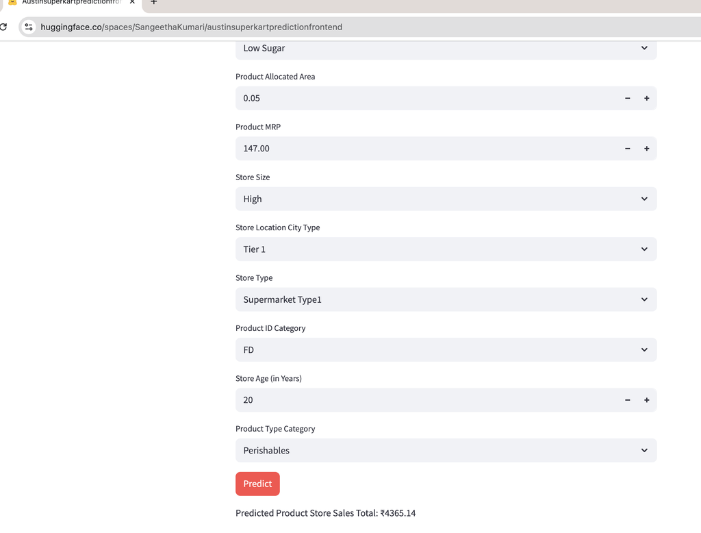

```python
from IPython.display import Image

Image('prediction.png', width=500)
```

# **Actionable Insights and Business Recommendations**

-Actionable Insights

- Prioritize High-Revenue Categories: The analysis shows that Fruits and Vegetables (14.3%) and Snack Foods (13.1%) are the primary revenue drivers.
- Capitalize on Health Trends: Over 50% of items sold are "Low Sugar."
- Optimize Shelf Space: The correlation matrix revealed that Product_Allocated_Area has a near-zero impact on sales.
- Revitalize Underperforming Outlets: OUT002 (Food Mart) in Tier 3 cities is significantly underperforming.
- Pricing Consistency: The analysis shows that Product_MRP is consistent across all store types

-Business Recommendation

- As mostly Fresh fruits and Vegetables are high revenue categories. Implement Just in time inventory system to avoid wastage
- Expanding the inventory for the "No Sugar" and "Low Sugar" segments, especially within the Snacks and Dairy categories, to provide customers with more healthier options.
- Stopping prioritizing large display areas for underperforming products. Instead, use that space for high-MRP items, which showed a strong positive correlation (0.79) with total sales.
- Maintain a unified pricing strategy to build brand trust, but consider localized "Bundle Discounts" in Tier 3 cities to increase the average transaction value.
- Use the Tuned Random Forest model ($R^2 = 0.6687$) to perform price-sensitivity analysis. By simulating changes in MRP for "Non-Perishable" goods, management can optimize pricing tiers to maximize total revenue.